# 1AI

# 4 Fits to FI indices

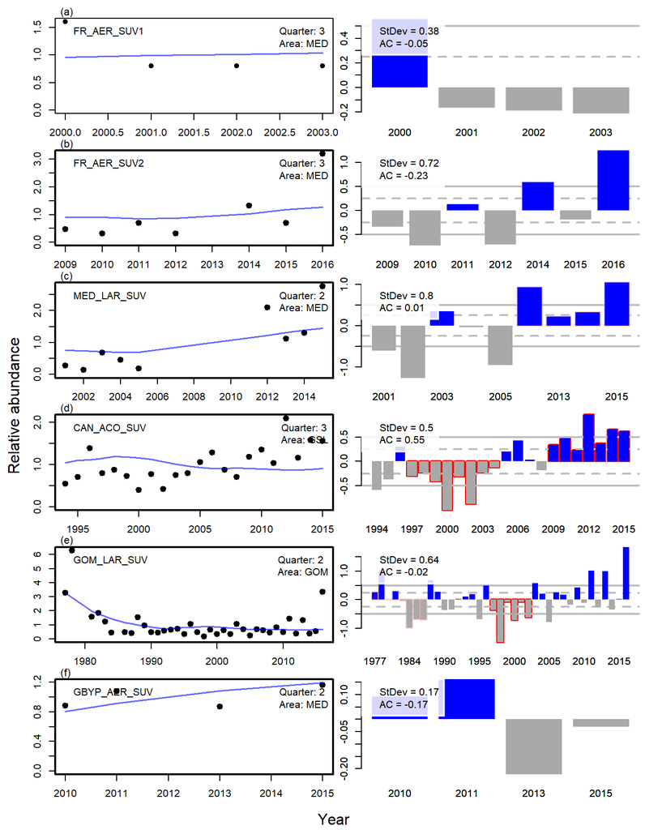

# 5 Spawning biomass

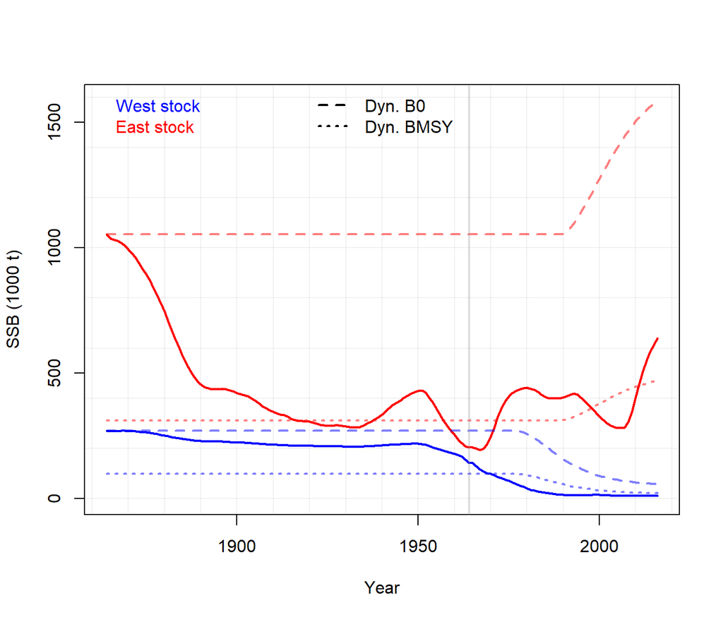

Figure 2a. Historical spawning biomass. Dynamic unfished spawning biomass (Dyn. B0) is calculated using year-specific estimates of recruitment strength assuming that there was zero fishing (ie it lags shifts in productivity). Dynamic BMSY is a fixed fraction of B0 based on the most recent estimates of BMSY relative to unfished.

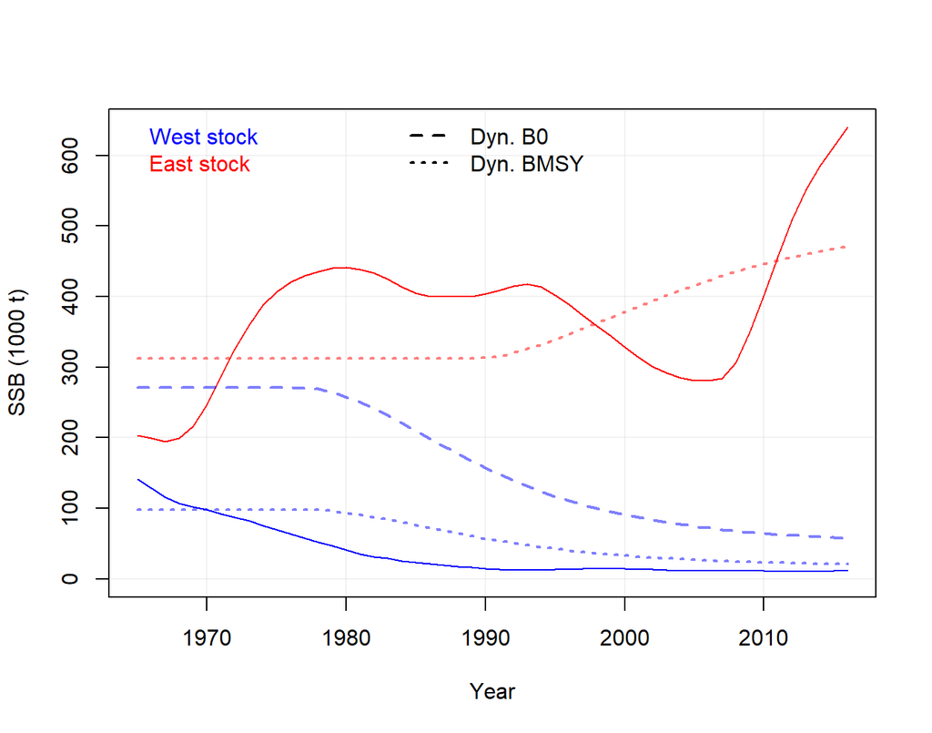

Figure 2b. Recent spawning biomass. Dynamic unfished spawning biomass (Dyn. B0) is calculated using year-specific estimates of recruitment strength assuming that there was zero fishing (ie it lags shifts in productivity). Dynamic BMSY is a fixed fraction of B0 based on the most recent estimates of BMSY relative to unfished.

# 6 Assessment comparison

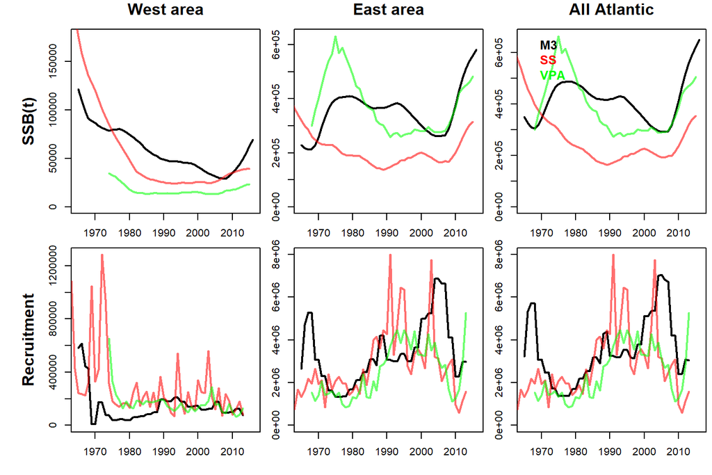

Figure 3.Regional comparisons (45deg W) with 2017 stock assessment. Note that annual estimates from the operating model are calculated from average of the seasonal predictions.

# 7 Stock-recruitment relationships

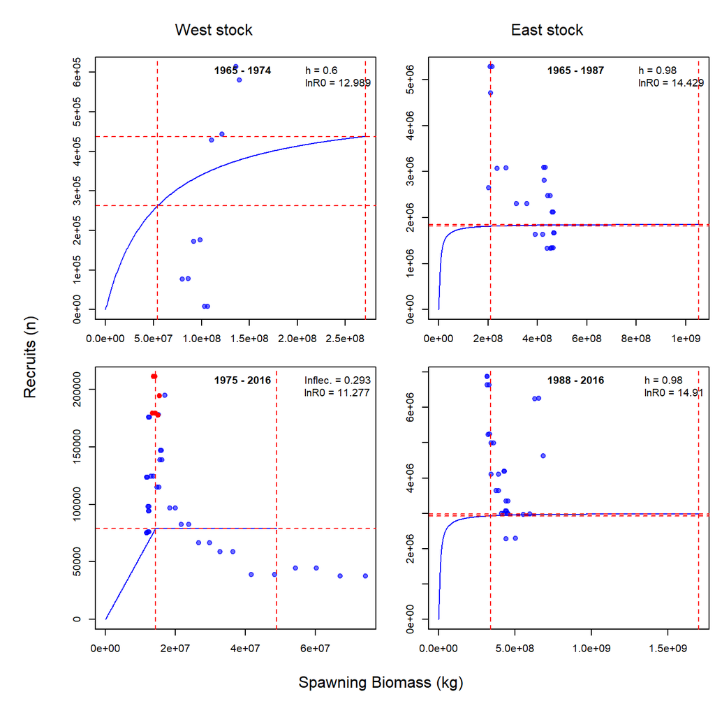

Figure 4. Model predicted spawning stock biomass and recruitment. h is the assumed value of steepness, lnR0 is the log unfished recruitment. In the case of the hockey stick SR model, Inflec. is the biomass position of the inflection (join) point relative to unfished.

# 8 MSY reference points

Table 1. 2015 Reference points by stock. MSY, BMSY, SSBMSY numbers are in tonnes.

|  | MSY | FMSYap | UMSY | BMSY | SSBMSY | BMSY_B0 | SSBMSY_SSB0 | RMSY_R0 | F_FMSY | SSB_SSB0 |
| --- | --- | --- | --- | --- | --- | --- | --- | --- | --- | --- |
| East stock | 52612 | 0.168 | 0.114 | 407193 | 455201 | 0.356 | 0.297 | 0.988 | 1.513 | 0.582 |
| West stock | 1327 | 0.109 | 0.082 | 14859 | 16381 | 0.404 | 0.363 | 0.831 | 2.346 | 0.041 |

Table 2. 2015 Reference points by stock using 1965 stock-recruitment. MSY, BMSY, SSBMSY numbers are in tonnes.

|  | MSY | FMSYap | UMSY | BMSY | SSBMSY | BMSY_B0 | SSBMSY_SSB0 | RMSY_R0 | F_FMSY | SSB_SSB0 |
| --- | --- | --- | --- | --- | --- | --- | --- | --- | --- | --- |
| East stock | 32548 | 0.168 | 0.114 | 251908 | 281608 | 0.356 | 0.297 | 0.988 | 1.513 | 0.582 |
| West stock | 6656 | 0.092 | 0.072 | 86300 | 95044 | 0.417 | 0.380 | 0.786 | 2.346 | 0.041 |

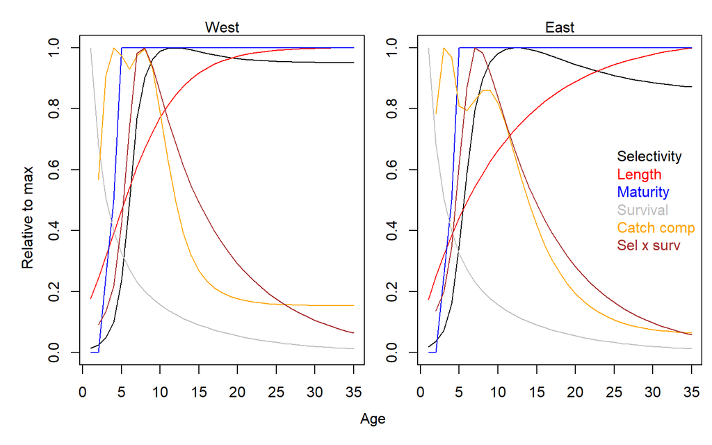

Figure 5. Age-specific quantities determining 2015 MSY reference points. Survival is based on natural mortality only. Catch comp (orange line) is the age composition of all catch at length data (converted to age via an ALK). Sel x surv is the unfished predicted age composition of catches based on 2015 selectivity (black line) and unfished age structure from survival (grey line). Sel x surv (brown line) provides an approximate check of the model approximation of catch composition. The sel x surv should be of higher age (to the right of) the catch comp that is from an exploited population.

# 9 Current F-at-age profile

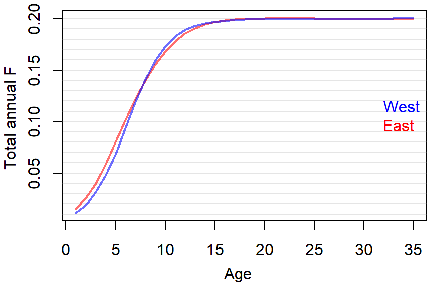

Figure 6. The current profile of F at age summed over all fleets, average weighed (by total contribution to annual F) over seasons and areas.

# 10 Estimated size selectivity

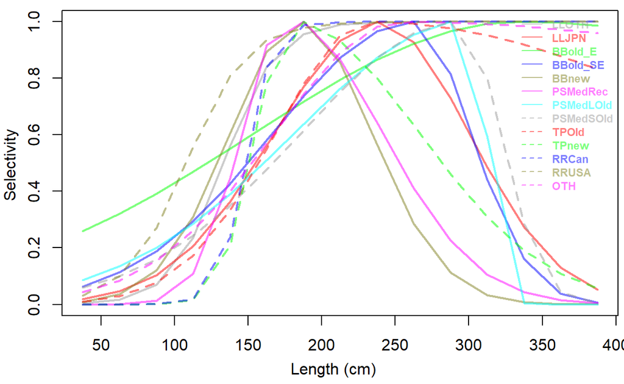

Figure 7.

# 11 Fit to aggregate catches

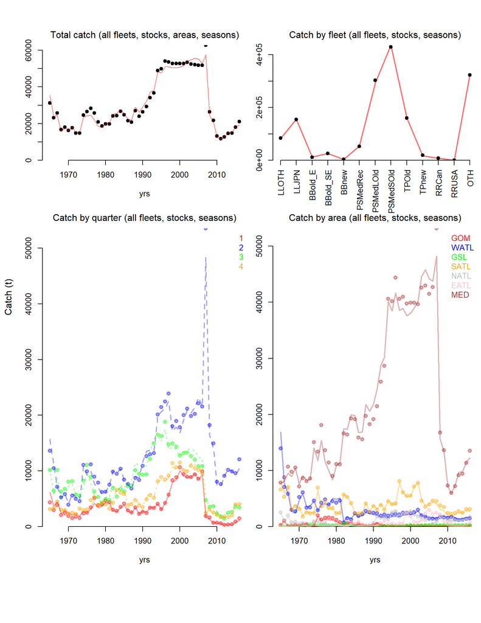

Figure 8. Fit to a observed total catches aggregated over various axes (lines = predicted, points = observed)

# 12 Fit to length composition

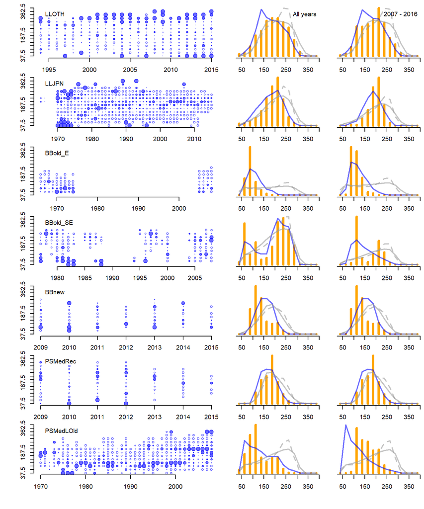

Figure 9a.Length composition residuals. Filled blue points are positive Pearson residuals (observed is higher than predicted), blue circles are negative residuals (observed is lower than predicted). Orange bars are observed, blue lines are model predictions. Grey lines show the predicted unfished composition of the Eastern stock (solid grey line) and the Western stocks (dashed grey line).

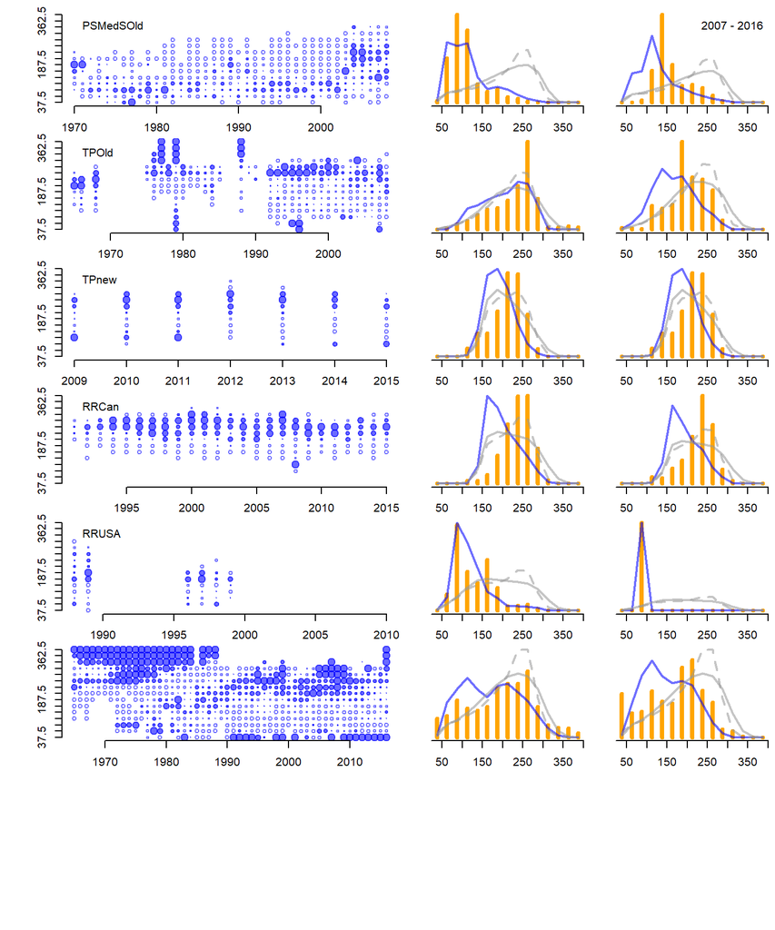

Figure 9b.Length composition residuals. Filled blue points are positive Pearson residuals (observed is higher than predicted), blue circles are negative residuals (observed is lower than predicted). Orange bars are observed, blue lines are model predictions. Grey lines show the predicted unfished composition of the Eastern stock (solid grey line) and the Western stocks (dashed grey line).

# 13 Spatial distribution

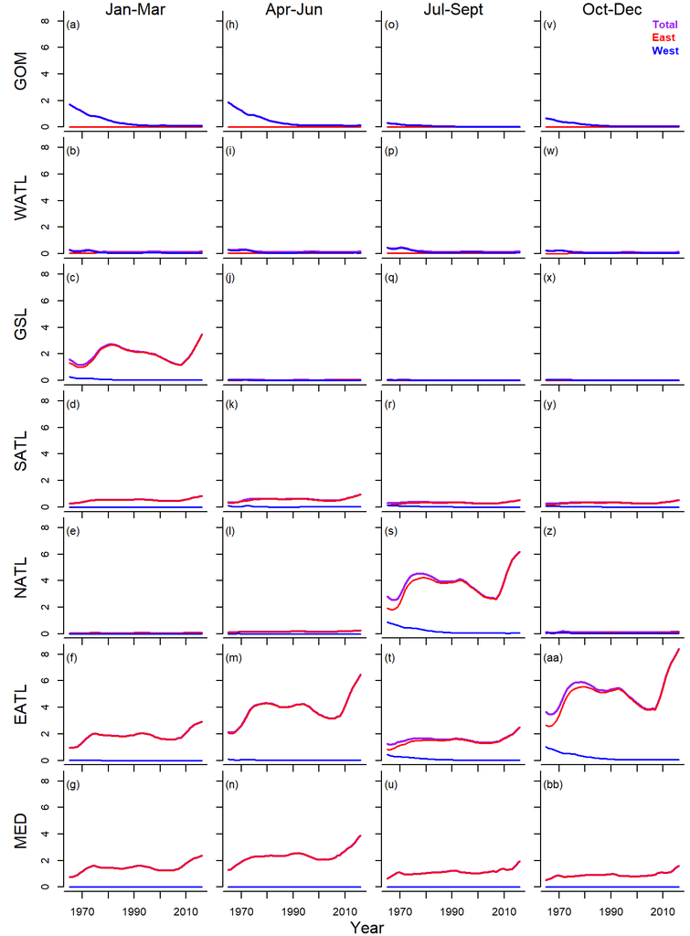

Figure 10. The predicted seasonal and spatial biomass of Atlantic bluefin tuna by stock.

# 14 Estimated unfished movement

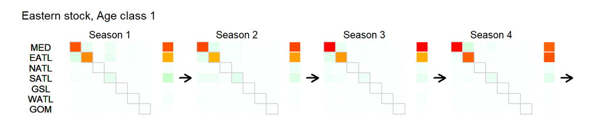

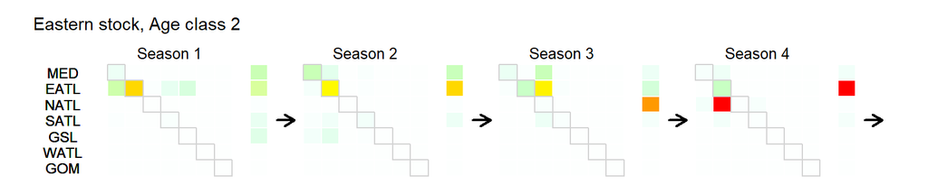

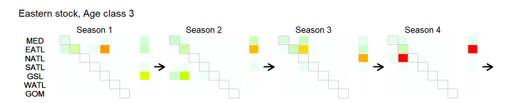

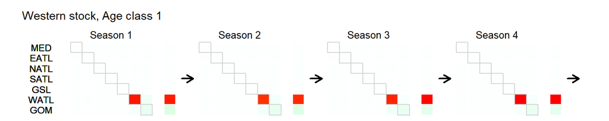

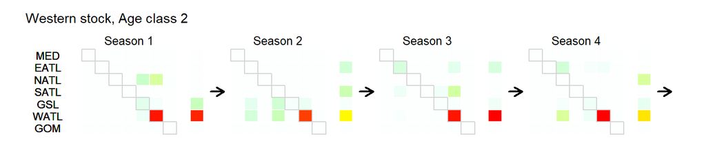

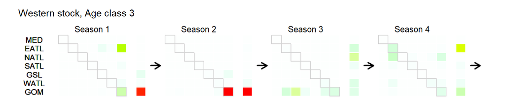

Figure 11. The implied asymptotic distribution of fish under unfished conditions (red-orange-green-white, more to less)

# 15 Observed versus prediced, stock of origin data

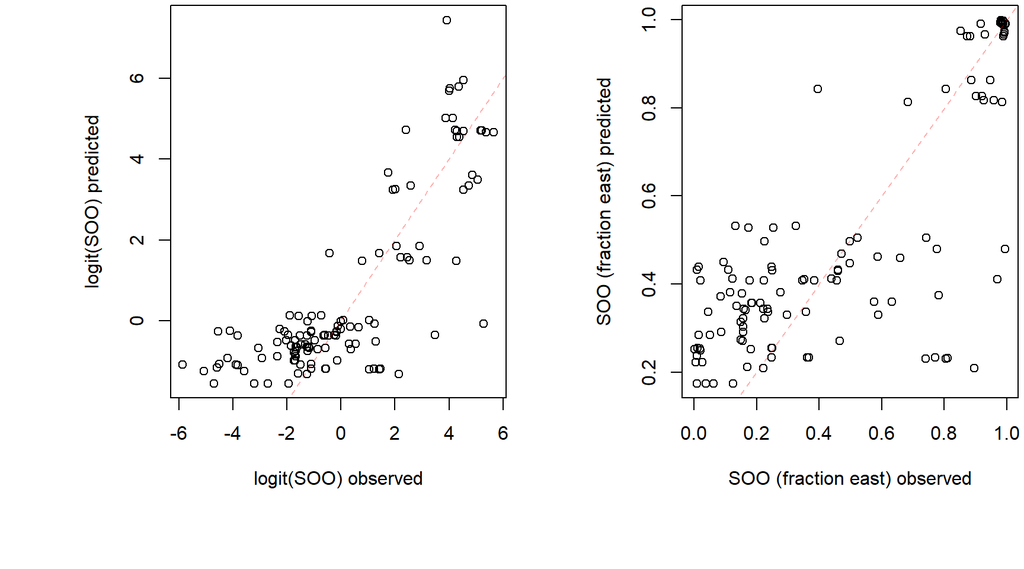

# 16 Obvserved versus predicted e-tag transitions (fraction moving to an area)

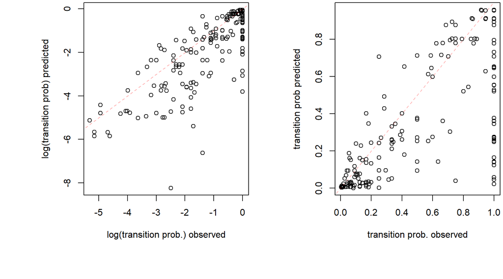

# 17 Obvserved versus predicted e-tag transitions (fraction moving to an area) for tags of unknown origin

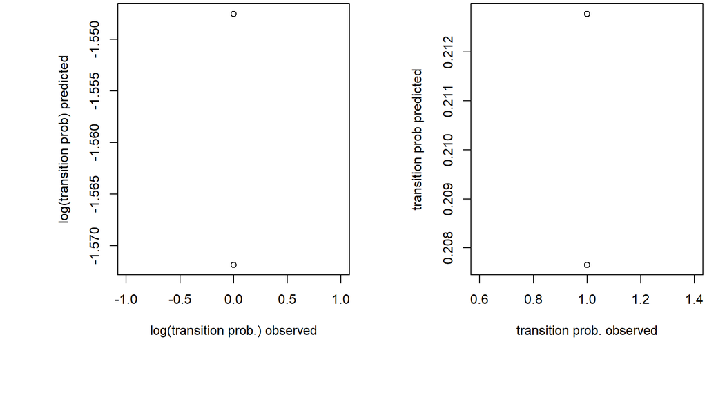